# Generalized linear models

Statistical Programming with R

## Content

1. Generalized linear model (GLM)
   - variables with non-normal error distribution
   - families and link functions
2. Dichotomous variables
   - binomial family
   - logit link function
   - logistic regression
3. Fit measures
   - Deviance vs \(R^2\)

## \(Y\) is continuous

The linear model applies to a **continuous** dependent variable \(Y\).

\[\mu=\beta_0+\beta{x}+\varepsilon, \ \ \ \ \ \varepsilon\sim{N}(0,\sigma^2)\]

- \(\mu\) is the mean of \(Y\) given the score on \(X\).
- Residuals are normally distributed and homoscedastic.

[figure not shown]

## \(Y\) is dichotomous

Dichotomous variables

```
- pass/fail the exam (pass = 1, fail = 0)

- smoker/non-smoker (smoker = 1, non-smoker = 0)
```

Predict the probability \(\mu=P(Y=1)\) with linear model

\[\mu=\beta_0+\beta{x}+\varepsilon, \ \ \ \ \ \varepsilon\sim{Bin}(n,p)\]

Problem:

- binomial error distribution (non-normal and heteroscedastic)
- estimates outside the inetrval \((0,1)\)

## Example passing the an exam

Distribution of variable `pass` for 100 students

- 80 students passed the exam \((pass = 1)\)
- 20 students failed the exam \((pass = 0)\)

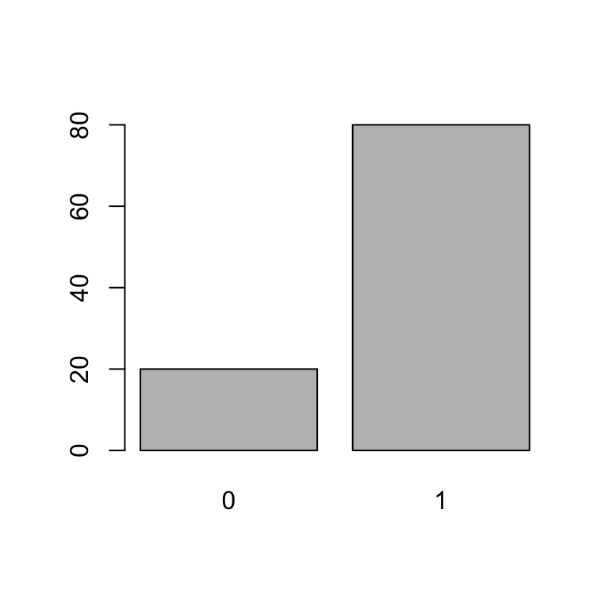

## Predictions from the linear model

Predict passing the exam for study time.

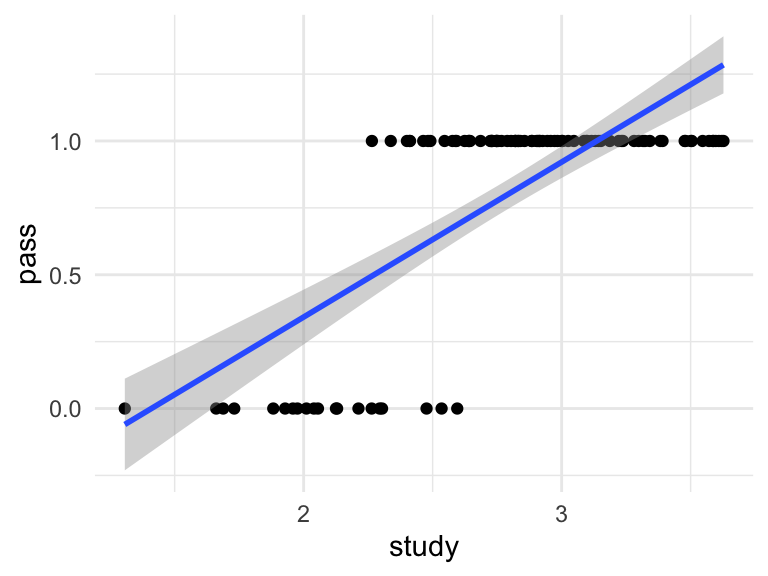

## Residual plots

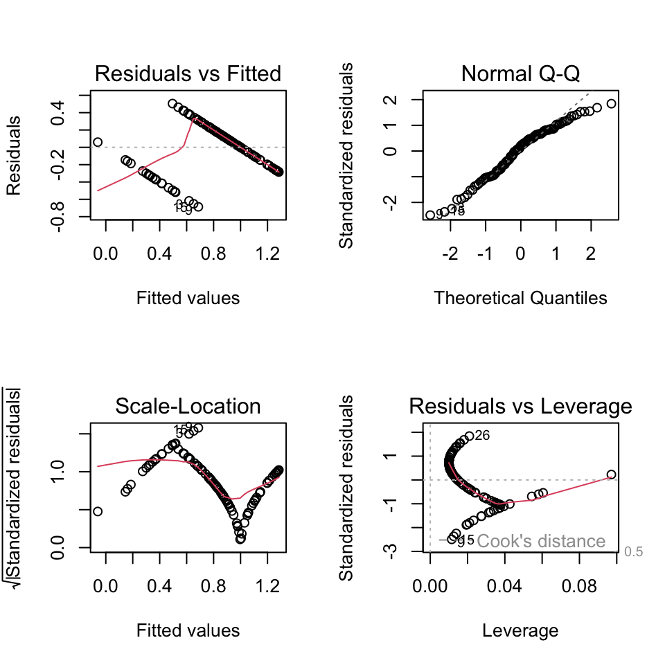

## Generalized Linear Model

The GLM does not predict \(\mu\) but a function of \(\mu\).

- The function \(g(\mu)\) is called the link function.

\[g(\mu)=\beta_0+\beta{x}+\varepsilon\]

The link function ensures that predictions are within the permitted range.

- between 0 and 1 for dichotomous variables

The GLM does not assume normality or homoscedasticity.

## Families of distributions

The GLM distinguishes various families of distributions, e.g.:

- gaussian family for continuous variables
- binomial family for dichotomous variables

| family | DV | link | \(g(\mu)=\beta_0+\beta{x}\) | \(\mu=g^{-1}(\beta_0+\beta{x})\) |
| --- | --- | --- | --- | --- |
| gaussian | continuous | identity | \(g(\mu)=\mu\) | \(\mu=\beta_0+\beta{x}\) |
| binomial | dichotomous | logit | \(g(\mu)=\log\frac{\mu}{1-\mu}\) | \(\mu=\frac{\exp(\beta_0+\beta{x})}{1+\exp(\beta_0+\beta{x})}\) |

## Fitting a GLM

As `lm()`, but with additional family argument:

```r
glm(formula, family = c("gaussian", "binomial"), data)
```

Predictions

```r
predict(object, type = c("link", "response")
```

- `object` is a fitted GLM model
- `type = "link"` for prediction of the linear predictor \(g(\mu)=\beta_0+\beta{x}\)
- `type = "response"` for prediction of the mean \(\mu=g^{-1}(\beta_0+\beta{x})\)

## Probability of passing the exams

Logistic regression model

```
Call:
glm(formula = pass ~ study, family = binomial)

Deviance Residuals:
     Min        1Q    Median        3Q       Max
-2.28293   0.00184   0.03104   0.15970   1.64812

Coefficients:
            Estimate Std. Error z value Pr(>|z|)
(Intercept)  -25.633      7.143  -3.589 0.000332 ***
study         10.851      2.948   3.680 0.000233 ***
---
Signif. codes:  0 '***' 0.001 '**' 0.01 '*' 0.05 '.' 0.1 ' ' 1

(Dispersion parameter for binomial family taken to be 1)

    Null deviance: 100.080  on 99  degrees of freedom
Residual deviance:  25.818  on 98  degrees of freedom
AIC: 29.818

Number of Fisher Scoring iterations: 8
```

## Interpretation parameter estimates

Parameter estimates are on the logit scale

\[logit(pass)=\log\frac{\mu}{1-\mu}=\beta_0+\beta{x}\]

Probability estimates are obtained via the inverse link):

\[P(pass)=\frac{\exp(\beta_0+\beta{x})}{1+\exp(\beta_0+\beta{x})}\]

Notice that \(P(pass)\) is always between 0 and 1!

## Regression line

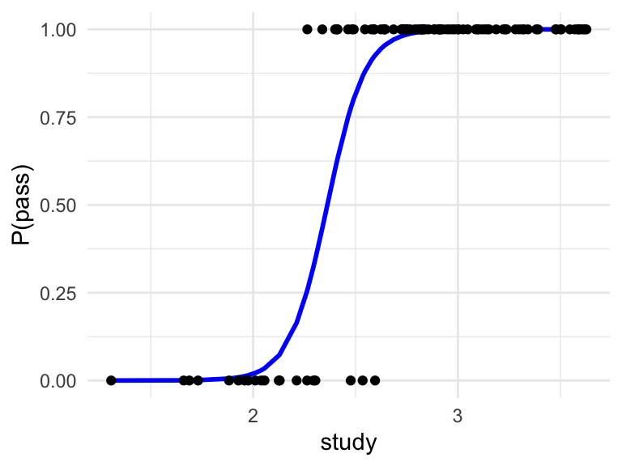

## Fit measures `lm()`

The linear model uses the \(F\) and \(R^2\) statistics

```
Call:
lm(formula = am ~ disp, data = mtcars)

Residuals:
    Min      1Q  Median      3Q     Max
-0.6696 -0.2989  0.0443  0.2786  0.8800

Coefficients:
              Estimate Std. Error t value Pr(>|t|)
(Intercept)  0.9554478  0.1547207   6.175 8.55e-07 ***
disp        -0.0023803  0.0005928  -4.015 0.000366 ***
---
Signif. codes:  0 '***' 0.001 '**' 0.01 '*' 0.05 '.' 0.1 ' ' 1

Residual standard error: 0.4091 on 30 degrees of freedom
Multiple R-squared:  0.3495,    Adjusted R-squared:  0.3279
F-statistic: 16.12 on 1 and 30 DF,  p-value: 0.0003662
```

## Fit measures `glm()`

```
Call:
glm(formula = am ~ disp, family = binomial, data = mtcars)

Deviance Residuals:
    Min       1Q   Median       3Q      Max
-1.5651  -0.6648  -0.2460   0.7276   2.2691

Coefficients:
             Estimate Std. Error z value Pr(>|z|)
(Intercept)  2.630849   1.050170   2.505  0.01224 *
disp        -0.014604   0.005168  -2.826  0.00471 **
---
Signif. codes:  0 '***' 0.001 '**' 0.01 '*' 0.05 '.' 0.1 ' ' 1

(Dispersion parameter for binomial family taken to be 1)

    Null deviance: 43.230  on 31  degrees of freedom
Residual deviance: 29.732  on 30  degrees of freedom
AIC: 33.732

Number of Fisher Scoring iterations: 5
```

## Deviance and AIC

Deviance is measure for difference between observed and fitted values

- `Null deviance`: deviance of intercept-only model
- `Residual Deviance`: deviance of fitted model

The larger the difference, the better the model

- `AIC`: model with the lowest AIC is the most parsimonious

## Example

Intercept-only model

```
Call:  glm(formula = pass ~ 1, family = binomial)

Coefficients:
(Intercept)
      1.386

Degrees of Freedom: 99 Total (i.e. Null);  99 Residual
Null Deviance:      100.1
Residual Deviance: 100.1    AIC: 102.1
```

Model with predictor `study`

```
Call:  glm(formula = pass ~ study, family = binomial)

Coefficients:
(Intercept)        study
     -25.63        10.85

Degrees of Freedom: 99 Total (i.e. Null);  98 Residual
Null Deviance:      100.1
Residual Deviance: 25.82    AIC: 29.82
```

## Summary

Generalized Linear Model

- variables with non-normal error distribution
- family and link function
- inverse link function (`type = “response”) is on the original scale of the DV
- fit is measured by the deviance and AIC